# Ford GoBike System Facts

### by Mohamed Samir Ahmed Assem

## Investigation Overview

> This Presentation provides insights conducted from FORD-Go Bike sharing system data for February 2019.

## Dataset Overview

> Dataset contains data about more than 180k trips occured during February 2019

## Who are the users

### Ages

> most users' ages are between 18 and 42 years old.

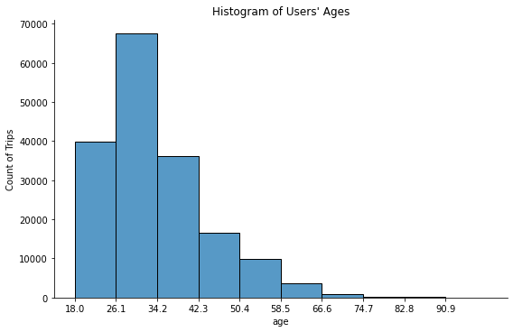

## Who are the users?

### Genders

> Male users represent 76% of total users

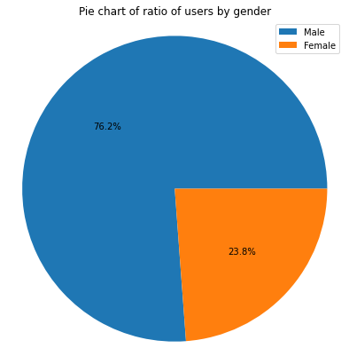

## Who are the users?

### Types

> 90.5% of users are subscribers.

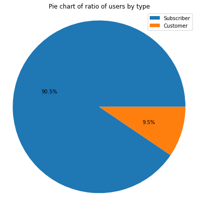

## Time of Day and Number of Trips

> Trip requests fall at night but customers' highest number of trips usually take place in the after noon.  
> Please note that:  
> Morning : 6.00 AM to 12:00 PM  
> Afternoon : 12:00 PM to 18:00 PM  
> Night : 18:00 PM to 06:00 AM

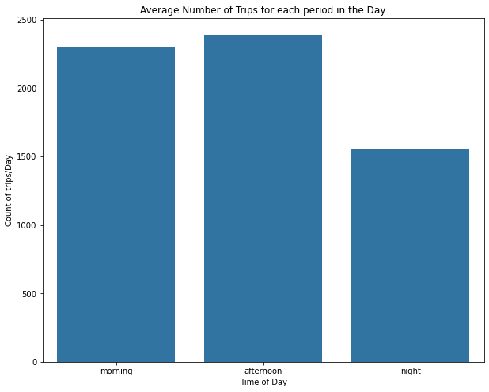

## Time of Day and Number of Trips

> Customers usually make more trips in the after noon.

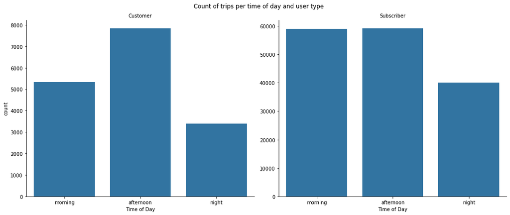

## Day of Week and Number of Trips

> Most trips take place on tuesday and thursday

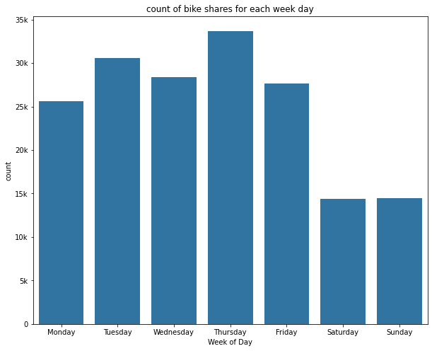

## Day of Week and Number of Trips

### User-Type

> Customers show less variable daily trip than subscribers who make less trips on Saturdays and Sundays

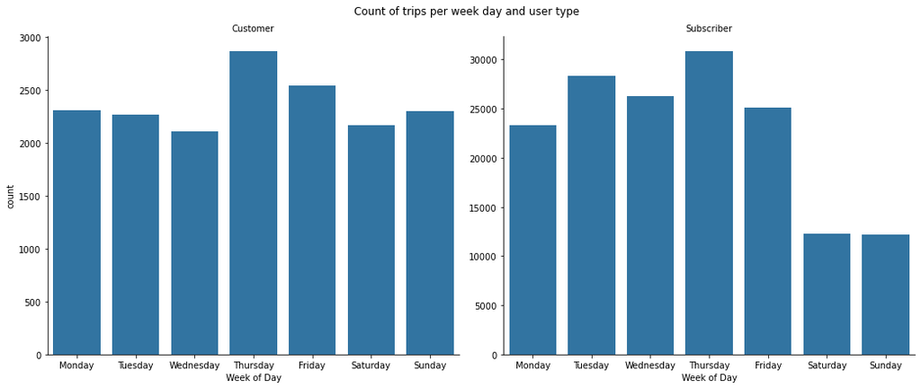

## Trip Duration

> Duration of trips follows a right skewed normal distribution, having an average of 11.7 minutes and minimum of 1 minute and maximum of 23.5 hrs, however 99.3% of trips are shorter than 62 minutes.

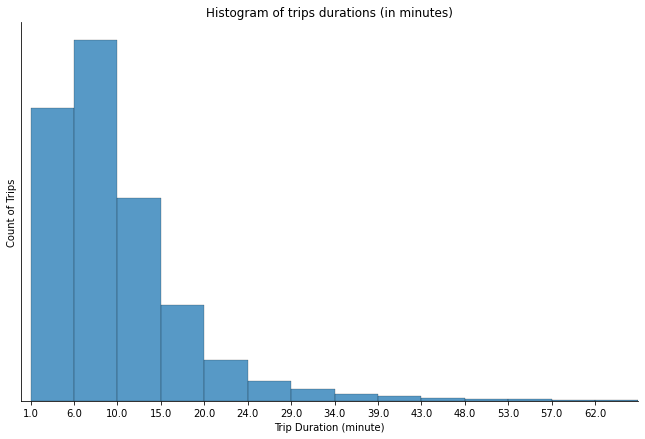

## Trip Duration and Day of Week

> Longer trips are in week ends!

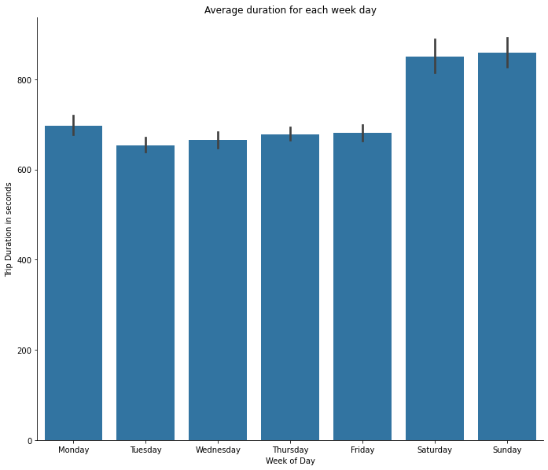

## Trip duration and User Type and Gender

> Customers seem to make longer trips than subscribers also females seem to make longer trips.

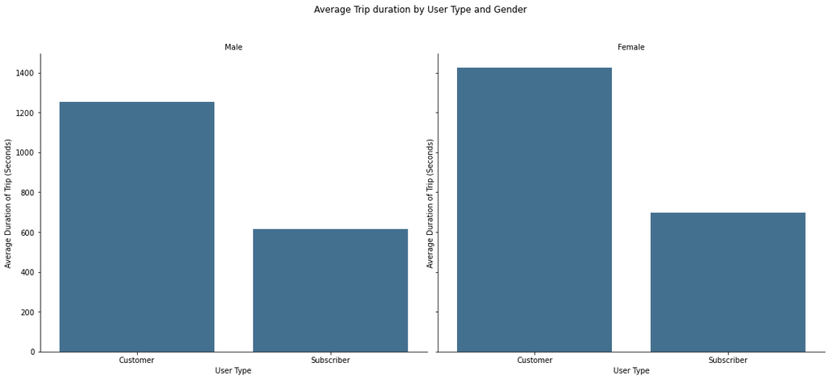